# Homework_09

Madelynn Edwards

2024-03-27

# Organizing Code with Structured Programming

#### 1.Use the code that you worked on in Homework #7 (creating fake data sets), and re-organize it following the principles of structured programming. Do all the work in a single chunk in your R markdown file, just as if you were writing a single R script. Start with all of your annotated functions, preliminary calls, and global variables. The program body should be only a few lines of code that call the appropriate functions and run them in the correct order. Make sure that the output from one function serves as the input to the next. You can either daisy-chain the functions or write separate lines of code to hold elements in temporary variables and pass them along.

```r
# FUNCTION: fakedata()
# Creating fake data set and data frame
# This function will create a fake data set using the means and standard deviations from a different data set
# nGroup : 3 treatments groups
# nName: Treatment names (Control, Low, High)
# nSize: sample size for each treatment (30, 27, 25)
# nMean: means for each group (68.37, 19.05, 12.84)
# nSD: Standard deviation for each group (16.58,19.05,12.84)
############################

library(tidyverse)
fakedata <- function(nGroup = 3, nName = c("Control","Low", "High"), nSize = c(30,27,25), nMean = c(68.37,51.15,30.46),nSD = c(16.58,19.05,12.84), ID = 1:(sum(nSize))) {
  Abundance <- c(rnorm(n=nSize[1],mean=nMean[1],sd=nSD[1]),
                 rnorm(n=nSize[2],mean=nMean[2],sd=nSD[2]),
                 rnorm(n=nSize[3],mean=nMean[3],sd=nSD[3]))
Treatment <- rep(nName,nSize)
ANOdata <- data.frame(ID,Treatment,Abundance)
str(ANOdata)
print(ANOdata)
  }

x <- fakedata()
```

```
## 'data.frame':    82 obs. of  3 variables:
##  $ ID       : int  1 2 3 4 5 6 7 8 9 10 ...
##  $ Treatment: chr  "Control" "Control" "Control" "Control" ...
##  $ Abundance: num  56.9 91.3 61.7 68.9 68.4 ...
##    ID Treatment  Abundance
## 1   1   Control  56.883128
## 2   2   Control  91.324722
## 3   3   Control  61.749348
## 4   4   Control  68.908503
## 5   5   Control  68.440128
## 6   6   Control  59.337628
## 7   7   Control  74.235414
## 8   8   Control  69.762626
## 9   9   Control  46.748244
## 10 10   Control  98.828270
```

[output cut: 72 more lines]

```r
fakedata()
```

```
## 'data.frame':    82 obs. of  3 variables:
##  $ ID       : int  1 2 3 4 5 6 7 8 9 10 ...
##  $ Treatment: chr  "Control" "Control" "Control" "Control" ...
##  $ Abundance: num  78.4 63.3 65.8 97.7 89.8 ...
##    ID Treatment Abundance
## 1   1   Control 78.367601
## 2   2   Control 63.328275
## 3   3   Control 65.789432
## 4   4   Control 97.703974
## 5   5   Control 89.838625
## 6   6   Control 72.640934
## 7   7   Control 64.297317
## 8   8   Control 78.320845
## 9   9   Control 90.055584
## 10 10   Control 31.006887
```

[output cut: 72 more lines]

```r
#############################
# FUNCTION: statsfunc()
# Statistical analysis on data : ANOVA
# Using x from fakedata

statsfunc <- function(ANOdata = x){
  abundanceAOV <- aov(Abundance~Treatment,data=ANOdata)
  print(abundanceAOV)
  print(summary(abundanceAOV))
}
 y <- statsfunc()
```

```
## Call:
##    aov(formula = Abundance ~ Treatment, data = ANOdata)
##
## Terms:
##                 Treatment Residuals
## Sum of Squares   17500.17  23376.23
## Deg. of Freedom         2        79
##
## Residual standard error: 17.20179
## Estimated effects may be unbalanced
##             Df Sum Sq Mean Sq F value   Pr(>F)
## Treatment    2  17500    8750   29.57 2.59e-10 ***
## Residuals   79  23376     296
## ---
## Signif. codes:  0 '***' 0.001 '**' 0.01 '*' 0.05 '.' 0.1 ' ' 1
```

```r
 y
```

```
##             Df Sum Sq Mean Sq F value   Pr(>F)
## Treatment    2  17500    8750   29.57 2.59e-10 ***
## Residuals   79  23376     296
## ---
## Signif. codes:  0 '***' 0.001 '**' 0.01 '*' 0.05 '.' 0.1 ' ' 1
```

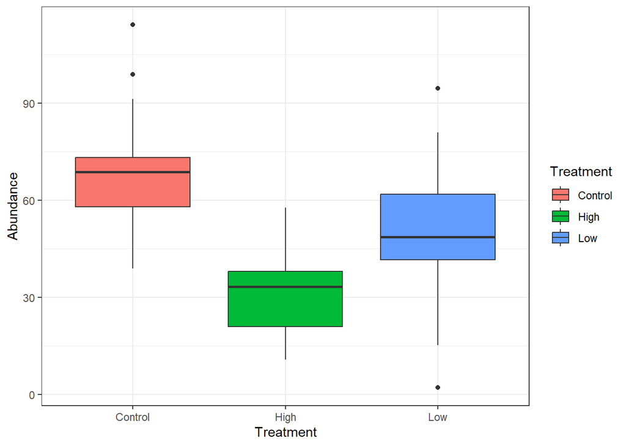

```r
################################
# FUNCTION: plotfunc()
# plotting the ANOVA results
#

library(ggplot2)

plotfunc <- function(ANOdata = x){
  ANOPlot <- ggplot(data=ANOdata,aes(x=Treatment,y=Abundance,fill=Treatment)) +
    geom_boxplot()+
    theme_bw()
  print(ANOPlot)
}
z <- plotfunc()
```

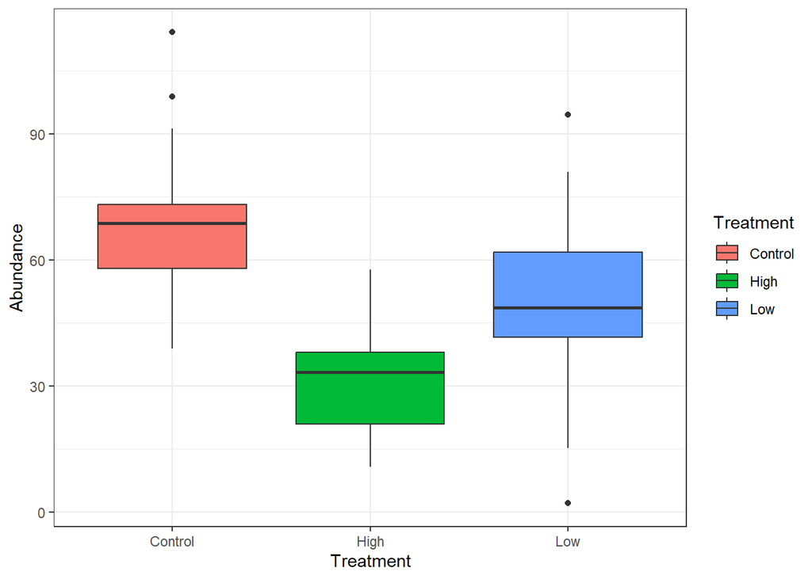

```r
z
```

#### 2. Once your code is up and working, modify your program to do something else: record a new summary variable, code a new statistical analysis, or create a different set of random variables or output graph. Do not rewrite any of your existing functions. Instead, copy them, rename them, and then modify them to do new things. Once your new functions are written, add some more lines of program code, calling a mixture of your previous functions and your new functions to get the job done.

```
##   Tukey multiple comparisons of means
##     95% family-wise confidence level
##
## Fit: aov(formula = Abundance ~ Treatment, data = data)
##
## $Treatment
##                   diff        lwr        upr     p adj
## High-Control -35.67723 -46.804320 -24.550146 0.0000000
## Low-Control  -19.02621 -29.926191  -8.126232 0.0002272
## Low-High      16.65102   5.246409  28.055635 0.0022831
```

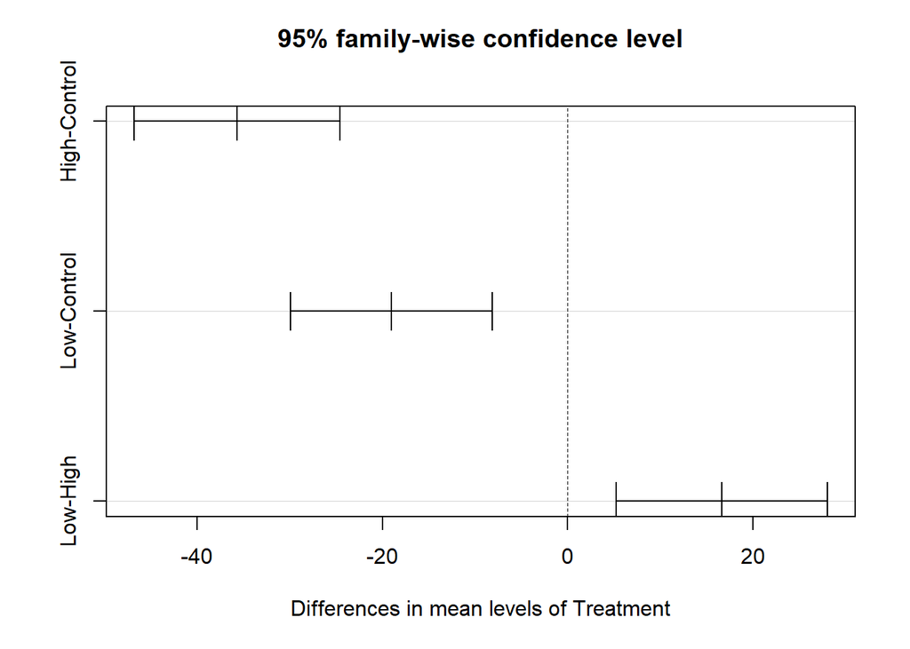

```r
# FUNCTION: posthocfunc()
# tukey post-hoc test
#

posthocfunc <- function(data = x) {
  abundanceAOV <- aov(Abundance~Treatment,data=data)
  tukey.test <- TukeyHSD(abundanceAOV)
  print(tukey.test)
  plot(tukey.test)
}
a <- posthocfunc()
```

```r
a
```